[GitHub](https://github.com/arviz-devs/ArviZ.jl)[](https://github.com/arviz-devs/ArviZ.jl/blob/main/docs/src/creating_custom_plots.jl)

# Creating custom plots

While ArviZ includes many plotting functions for visualizing the data stored in `InferenceData` objects, you will often need to construct custom plots, or you may want to tweak some of our plots in your favorite plotting package.

In this tutorial, we will show you a few useful techniques you can use to construct these plots using Julia's plotting packages. For demonstration purposes, we'll use Makie.jl and AlgebraOfGraphics.jl, which can consume `Dataset` objects since they implement the Tables interface. However, we could just as easily have used StatsPlots.jl.

```julia
begin
    using ArviZ, ArviZExampleData, DimensionalData, DataFrames, Statistics
    using AlgebraOfGraphics, CairoMakie
    using AlgebraOfGraphics: density
    set_aog_theme!()
end;
```

```julia
idata = load_example_data("centered_eight")
```

InferenceData

**posterior**

```
┌ 500×4×8 Dataset ┐
├─────────────────┴───────────────────────────────────────────── dims ┐
  ↓ draw Sampled{Int64} [0, …, 499] ForwardOrdered Irregular Points,
  → chain Sampled{Int64} [0, …, 3] ForwardOrdered Irregular Points,
  ↗ school Categorical{String} ["Choate", …, "Mt. Hermon"] Unordered
├───────────────────────────────────────────────────────────── layers ┤
  :mu    eltype: Float64 dims: draw, chain size: 500×4
  :theta eltype: Float64 dims: school, draw, chain size: 8×500×4
  :tau   eltype: Float64 dims: draw, chain size: 500×4
├─────────────────────────────────────────────────────────── metadata ┤
  Dict{String, Any} with 6 entries:
  "created_at" => "2025-01-19T14:32:33.071271+00:00"
  "inference_library_version" => "5.20.0"
  "sampling_time" => 3.15909
  "tuning_steps" => 1000
  "arviz_version" => "0.20.0"
  "inference_library" => "pymc"
```

**posterior_predictive**

```
┌ 8×500×4 Dataset ┐
├─────────────────┴────────────────────────────────────────────── dims ┐
  ↓ school Categorical{String} ["Choate", …, "Mt. Hermon"] Unordered,
  → draw Sampled{Int64} [0, …, 499] ForwardOrdered Irregular Points,
  ↗ chain Sampled{Int64} [0, …, 3] ForwardOrdered Irregular Points
├────────────────────────────────────────────────────────────── layers ┤
  :obs eltype: Float64 dims: school, draw, chain size: 8×500×4
├──────────────────────────────────────────────────────────── metadata ┤
  Dict{String, Any} with 4 entries:
  "created_at" => "2025-01-19T14:32:33.992006+00:00"
  "inference_library_version" => "5.20.0"
  "arviz_version" => "0.20.0"
  "inference_library" => "pymc"
```

**log_likelihood**

```
┌ 8×500×4 Dataset ┐
├─────────────────┴────────────────────────────────────────────── dims ┐
  ↓ school Categorical{String} ["Choate", …, "Mt. Hermon"] Unordered,
  → draw Sampled{Int64} [0, …, 499] ForwardOrdered Irregular Points,
  ↗ chain Sampled{Int64} [0, …, 3] ForwardOrdered Irregular Points
├────────────────────────────────────────────────────────────── layers ┤
  :obs eltype: Float64 dims: school, draw, chain size: 8×500×4
├──────────────────────────────────────────────────────────── metadata ┤
  Dict{String, Any} with 4 entries:
  "created_at" => "2025-01-19T14:32:33.869112+00:00"
  "inference_library_version" => "5.20.0"
  "arviz_version" => "0.20.0"
  "inference_library" => "pymc"
```

**sample_stats**

```
┌ 500×4 Dataset ┐
├───────────────┴──────────────────────────────────────────────────────── dims ┐
  ↓ draw Sampled{Int64} [0, …, 499] ForwardOrdered Irregular Points,
  → chain Sampled{Int64} [0, …, 3] ForwardOrdered Irregular Points
├────────────────────────────────────────────────────────────────────── layers ┤
  :step_size             eltype: Float64 dims: draw, chain size: 500×4
  :reached_max_treedepth eltype: Bool dims: draw, chain size: 500×4
  :perf_counter_start    eltype: Float64 dims: draw, chain size: 500×4
  :energy_error          eltype: Float64 dims: draw, chain size: 500×4
  :perf_counter_diff     eltype: Float64 dims: draw, chain size: 500×4
  :tree_depth            eltype: Int64 dims: draw, chain size: 500×4
  :process_time_diff     eltype: Float64 dims: draw, chain size: 500×4
  :n_steps               eltype: Float64 dims: draw, chain size: 500×4
  :max_energy_error      eltype: Float64 dims: draw, chain size: 500×4
  :step_size_bar         eltype: Float64 dims: draw, chain size: 500×4
  :lp                    eltype: Float64 dims: draw, chain size: 500×4
  :index_in_trajectory   eltype: Int64 dims: draw, chain size: 500×4
  :acceptance_rate       eltype: Float64 dims: draw, chain size: 500×4
  :smallest_eigval       eltype: Union{Missing, Float64} dims: draw, chain size: 500×4
  :energy                eltype: Float64 dims: draw, chain size: 500×4
  :diverging             eltype: Bool dims: draw, chain size: 500×4
  :largest_eigval        eltype: Union{Missing, Float64} dims: draw, chain size: 500×4
├──────────────────────────────────────────────────────────────────── metadata ┤
  Dict{String, Any} with 6 entries:
  "created_at" => "2025-01-19T14:32:33.083969+00:00"
  "inference_library_version" => "5.20.0"
  "sampling_time" => 3.15909
  "tuning_steps" => 1000
  "arviz_version" => "0.20.0"
  "inference_library" => "pymc"
```

**prior**

```
┌ 8×500×1 Dataset ┐
├─────────────────┴────────────────────────────────────────────── dims ┐
  ↓ school Categorical{String} ["Choate", …, "Mt. Hermon"] Unordered,
  → draw Sampled{Int64} [0, …, 499] ForwardOrdered Irregular Points,
  ↗ chain Sampled{Int64} [0] ForwardOrdered Irregular Points
├────────────────────────────────────────────────────────────── layers ┤
  :theta eltype: Float64 dims: school, draw, chain size: 8×500×1
  :tau   eltype: Float64 dims: draw, chain size: 500×1
  :mu    eltype: Float64 dims: draw, chain size: 500×1
├──────────────────────────────────────────────────────────── metadata ┤
  Dict{String, Any} with 4 entries:
  "created_at" => "2025-01-19T14:32:29.212688+00:00"
  "inference_library_version" => "5.20.0"
  "arviz_version" => "0.20.0"
  "inference_library" => "pymc"
```

**prior_predictive**

```
┌ 8×500×1 Dataset ┐
├─────────────────┴────────────────────────────────────────────── dims ┐
  ↓ school Categorical{String} ["Choate", …, "Mt. Hermon"] Unordered,
  → draw Sampled{Int64} [0, …, 499] ForwardOrdered Irregular Points,
  ↗ chain Sampled{Int64} [0] ForwardOrdered Irregular Points
├────────────────────────────────────────────────────────────── layers ┤
  :obs eltype: Float64 dims: school, draw, chain size: 8×500×1
├──────────────────────────────────────────────────────────── metadata ┤
  Dict{String, Any} with 4 entries:
  "created_at" => "2025-01-19T14:32:29.215699+00:00"
  "inference_library_version" => "5.20.0"
  "arviz_version" => "0.20.0"
  "inference_library" => "pymc"
```

**observed_data**

```
┌ 8-element Dataset ┐
├───────────────────┴──────────────────────────────────────────── dims ┐
  ↓ school Categorical{String} ["Choate", …, "Mt. Hermon"] Unordered
├────────────────────────────────────────────────────────────── layers ┤
  :obs eltype: Float64 dims: school size: 8
├──────────────────────────────────────────────────────────── metadata ┤
  Dict{String, Any} with 4 entries:
  "created_at" => "2025-01-19T14:32:29.216855+00:00"
  "inference_library_version" => "5.20.0"
  "arviz_version" => "0.20.0"
  "inference_library" => "pymc"
```

**constant_data**

```
┌ 8-element Dataset ┐
├───────────────────┴──────────────────────────────────────────── dims ┐
  ↓ school Categorical{String} ["Choate", …, "Mt. Hermon"] Unordered
├────────────────────────────────────────────────────────────── layers ┤
  :sigma eltype: Float64 dims: school size: 8
├──────────────────────────────────────────────────────────── metadata ┤
  Dict{String, Any} with 4 entries:
  "created_at" => "2025-01-19T14:32:29.217914+00:00"
  "inference_library_version" => "5.20.0"
  "arviz_version" => "0.20.0"
  "inference_library" => "pymc"
```

```julia
idata.posterior
```

[output not shown]

The plotting functions we'll be using interact with a tabular view of a `Dataset`. Let's see what that view looks like for a `Dataset`:

```julia
df = DataFrame(idata.posterior)
```

|  | draw | chain | school | mu | theta | tau |
| --- | --- | --- | --- | --- | --- | --- |
| 1 | 0 | 0 | "Choate" | 1.71572 | 2.31739 | 0.877494 |
| 2 | 1 | 0 | "Choate" | 1.90348 | 0.88917 | 0.802714 |
| 3 | 2 | 0 | "Choate" | 1.90348 | 0.88917 | 0.802714 |
| 4 | 3 | 0 | "Choate" | 1.90348 | 0.88917 | 0.802714 |
| 5 | 4 | 0 | "Choate" | 2.0175 | 1.10912 | 0.767934 |
| 6 | 5 | 0 | "Choate" | 1.67462 | 2.11367 | 0.844587 |
| 7 | 6 | 0 | "Choate" | 2.16297 | 3.22908 | 1.62637 |
| 8 | 7 | 0 | "Choate" | 2.73336 | 2.37819 | 2.41535 |
| 9 | 8 | 0 | "Choate" | 0.635038 | 2.56258 | 3.57007 |
| 10 | 9 | 0 | "Choate" | 0.550432 | -2.42224 | 2.11321 |
| ... |  |  |  |  |  |  |
| 16000 | 499 | 3 | "Mt. Hermon" | 10.2372 | 14.0231 | 3.05156 |

The tabular view includes dimensions and variables as columns.

When variables with different dimensions are flattened into a tabular form, there's always some duplication of values. As a simple case, note that `chain`, `draw`, and `school` all have repeated values in the above table.

In this case, `theta` has the `school` dimension, but `tau` doesn't, so the values of `tau` will be repeated in the table for each value of `school`.

```julia
df[df.school .== Ref("Choate"), :].tau == df[df.school .== Ref("Deerfield"), :].tau
```

```
true
```

In our first example, this will be important.

Here, let's construct a trace plot. Besides `idata`, all functions and types in the following cell are defined in AlgebraOfGraphics or Makie:

- `data(...)` indicates that the wrapped object implements the Tables interface
- `mapping` indicates how the data should be used. The symbols are all column names in the table, which for us are our variable names and dimensions.
- `visual` specifies how the data should be converted to a plot.
- `Lines` is a plot type defined in Makie.
- `draw` takes this combination and plots it.

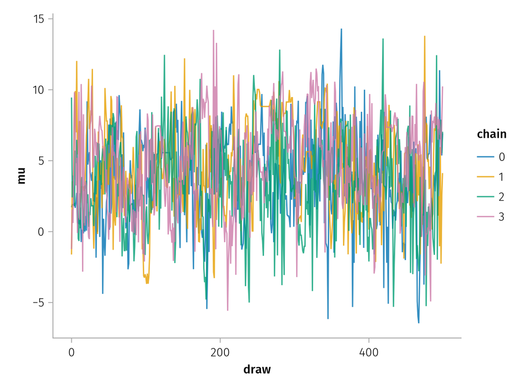

```julia
draw(
    data(idata.posterior.mu) *
    mapping(:draw, :mu; color=:chain => nonnumeric) *
    visual(Lines; alpha=0.8),
)
```

Note the line `idata.posterior.mu`. If we had just used `idata.posterior`, the plot would have looked more-or-less the same, but there would be artifacts due to `mu` being copied many times. By selecting `mu` directly, all other dimensions are discarded, so each value of `mu` appears in the plot exactly once.

When examining an MCMC trace plot, we want to see a "fuzzy caterpillar". Instead we see a few places where the Markov chains froze. We can do the same for `theta` as well, but it's more useful here to separate these draws by `school`.

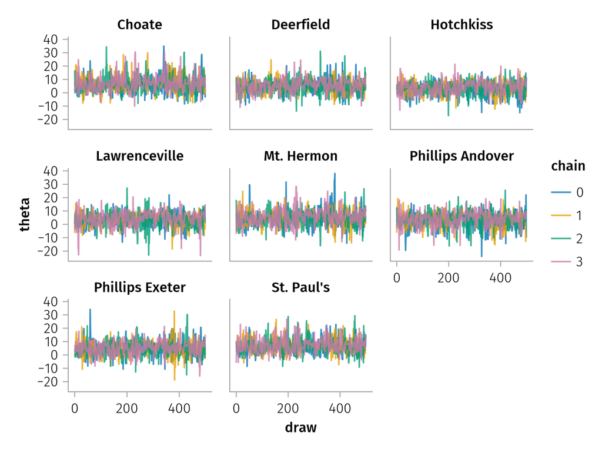

```julia
draw(
    data(idata.posterior) *
    mapping(:draw, :theta; layout=:school, color=:chain => nonnumeric) *
    visual(Lines; alpha=0.8),
)
```

Suppose we want to compare `tau` with `theta` for two different schools. To do so, we use `InferenceData`s indexing syntax to subset the data.

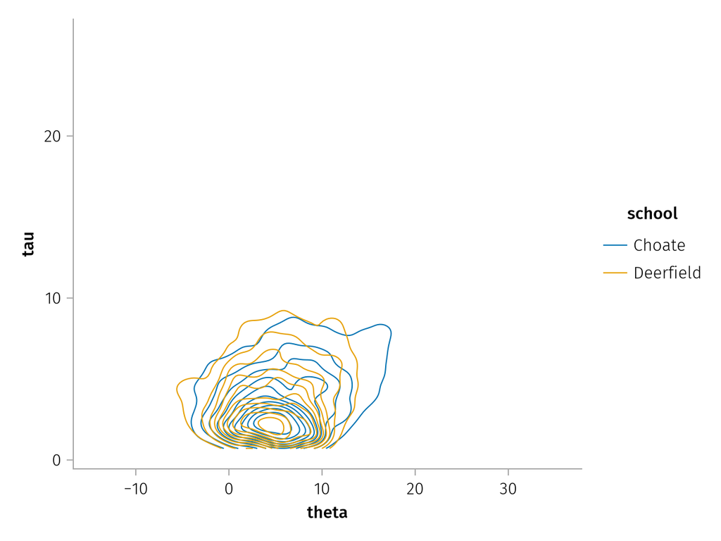

```julia
draw(
    data(idata[:posterior, school=At(["Choate", "Deerfield"])]) *
    mapping(:theta, :tau; color=:school) *
    density() *
    visual(Contour; levels=10),
)
```

We can also compare the density plots constructed from each chain for different schools.

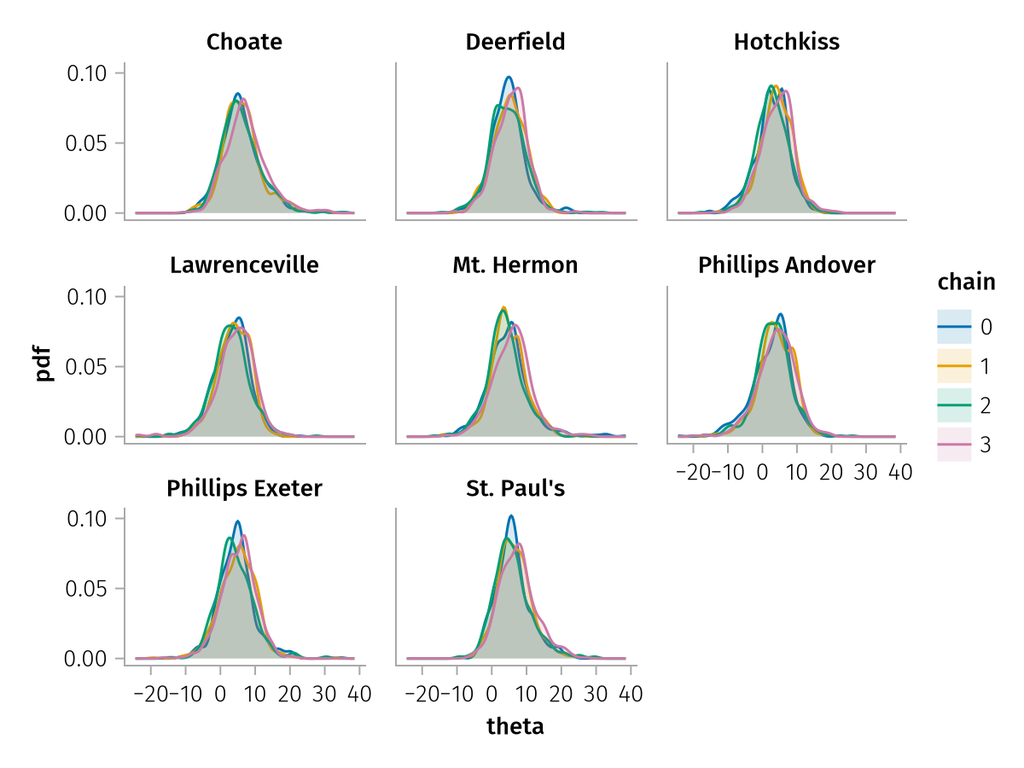

```julia
draw(
    data(idata.posterior) *
    mapping(:theta; layout=:school, color=:chain => nonnumeric) *
    density(),
)
```

If we want to compare many schools in a single plot, an ECDF plot is more convenient.

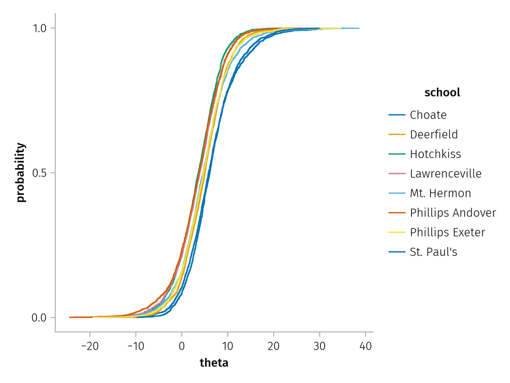

```julia
draw(
    data(idata.posterior) * mapping(:theta; color=:school => nonnumeric) * visual(ECDFPlot);
    axis=(; ylabel="probability"),
)
```

So far we've just plotted data from one group, but we often want to combine data from multiple groups in one plot. The simplest way to do this is to create the plot out of multiple layers. Here we use this approach to plot the observations over the posterior predictive distribution.

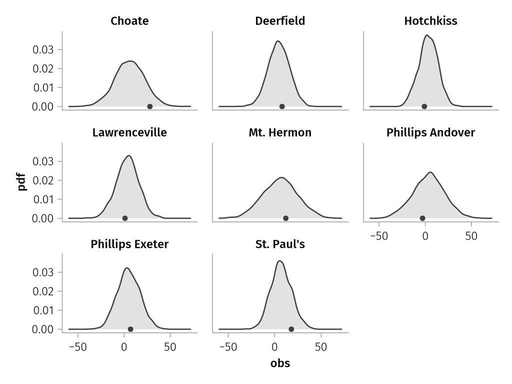

```julia
draw(
    (data(idata.posterior_predictive) * mapping(:obs; layout=:school) * density()) +
    (data(idata.observed_data) * mapping(:obs, :obs => zero => ""; layout=:school)),
)
```

Another option is to combine the groups into a single dataset.

Here we compare the prior and posterior. Since the prior has 1 chain and the posterior has 4 chains, if we were to combine them into a table, the structure would need to be ragged. This is not currently supported.

We can then either plot the two distributions separately as we did before, or we can compare a single chain from each group. This is what we'll do here. To concatenate the two groups, we introduce a new named dimension using `DimensionalData.Dim`.

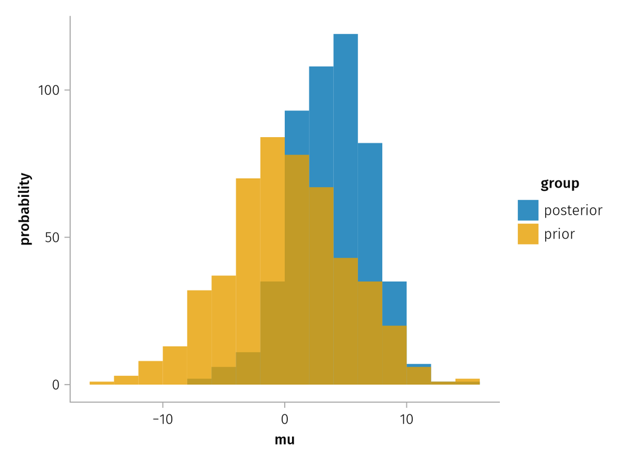

```julia
draw(
    data(
        cat(
            idata.posterior[chain=[1]], idata.prior; dims=Dim{:group}([:posterior, :prior])
        )[:mu],
    ) *
    mapping(:mu; color=:group) *
    histogram(; bins=20) *
    visual(; alpha=0.8);
    axis=(; ylabel="probability"),
)
```

From the trace plots, we suspected the geometry of this posterior was bad. Let's highlight divergent transitions. To do so, we merge `posterior` and `samplestats`, which can do with `merge` since they share no common variable names.

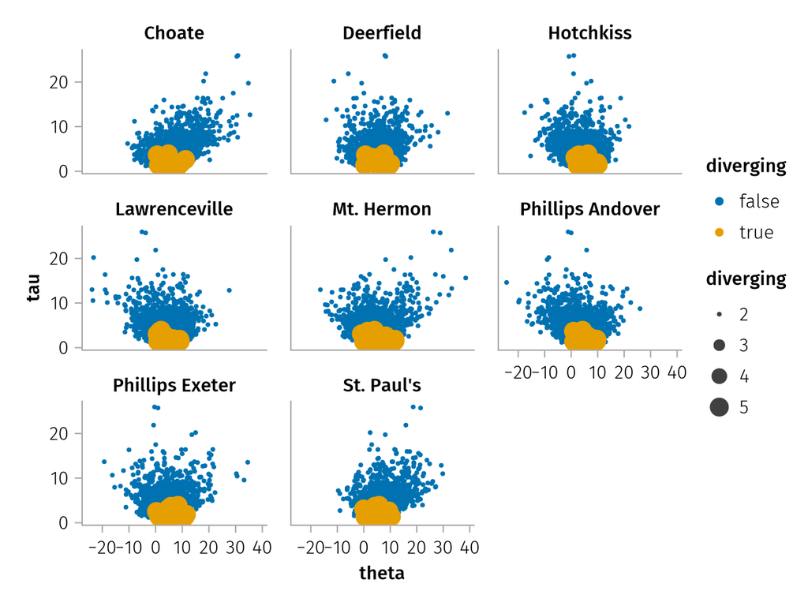

```julia
draw(
    data(merge(idata.posterior, idata.sample_stats)) * mapping(
        :theta,
        :tau;
        layout=:school,
        color=:diverging,
        markersize=:diverging => (d -> d ? 5 : 2),
    ),
)
```

When we try building more complex plots, we may need to build new `Dataset`s from our existing ones.

One example of this is the corner plot. To build this plot, we need to make a copy of `theta` with a copy of the `school` dimension.

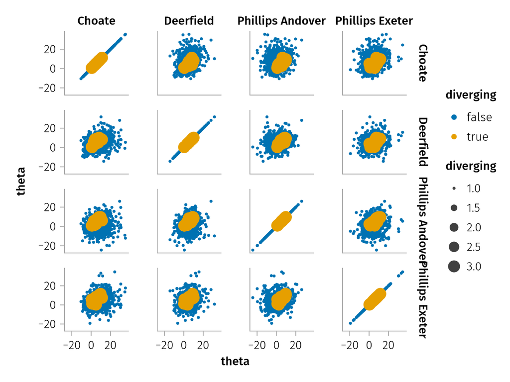

```julia
let
    theta = idata.posterior.theta[school=1:4]
    theta2 = rebuild(set(theta; school=:school2); name=:theta2)
    plot_data = Dataset(theta, theta2, idata.sample_stats.diverging)
    draw(
        data(plot_data) * mapping(
            :theta,
            :theta2 => "theta";
            col=:school,
            row=:school2,
            color=:diverging,
            markersize=:diverging => (d -> d ? 3 : 1),
        );
        figure=(; figsize=(5, 5)),
        axis=(; aspect=1),
    )
end
```

## Environment

```julia
using Pkg, InteractiveUtils
```

```julia
using PlutoUI
```

```julia
with_terminal(Pkg.status; color=false)
```

```
Status `~/work/ArviZ.jl/ArviZ.jl/docs/Project.toml`
⌃ [cbdf2221] AlgebraOfGraphics v0.11.10
  [131c737c] ArviZ v0.14.0 `~/work/ArviZ.jl/ArviZ.jl`
  [2f96bb34] ArviZExampleData v0.3.0
  [4a6e88f0] ArviZPythonPlots v0.1.13
  [13f3f980] CairoMakie v0.15.8
  [a93c6f00] DataFrames v1.8.1
  [0703355e] DimensionalData v0.29.25
  [31c24e10] Distributions v0.25.123
  [e30172f5] Documenter v1.16.1
  [d12716ef] DocumenterInterLinks v1.1.0
  [f6006082] EvoTrees v0.18.3
  [b5cf5a8d] InferenceObjects v0.4.15
  [2ab3a3ac] LogExpFunctions v0.3.29
  [be115224] MCMCDiagnosticTools v0.3.16
⌃ [a7f614a8] MLJBase v1.10.0
  [614be32b] MLJIteration v0.6.4
  [ce719bf2] PSIS v0.9.8
  [359b1769] PlutoStaticHTML v7.0.9
  [7f904dfe] PlutoUI v0.7.79
  [7f36be82] PosteriorStats v0.4.4
  [c1514b29] StanSample v7.10.2
  [a19d573c] StatisticalMeasures v0.3.4
  [10745b16] Statistics v1.11.1
  [2913bbd2] StatsBase v0.34.10
⌅ [fce5fe82] Turing v0.41.4
  [f43a241f] Downloads v1.7.0
  [37e2e46d] LinearAlgebra v1.12.0
Info Packages marked with ⌃ and ⌅ have new versions available. Those with ⌃ may be upgradable, but those with ⌅ are restricted by compatibility constraints from upgrading. To see why use `status --outdated`
```

```julia
with_terminal(versioninfo)
```

```
Julia Version 1.12.4
Commit 01a2eadb047 (2026-01-06 16:56 UTC)
Build Info:
  Official https://julialang.org release
Platform Info:
  OS: Linux (x86_64-linux-gnu)
  CPU: 4 × AMD EPYC 7763 64-Core Processor
  WORD_SIZE: 64
  LLVM: libLLVM-18.1.7 (ORCJIT, znver3)
  GC: Built with stock GC
Threads: 2 default, 1 interactive, 2 GC (on 4 virtual cores)
Environment:
  JULIA_PKG_SERVER_REGISTRY_PREFERENCE = eager
  JULIA_NUM_THREADS = 2
  JULIA_REVISE_WORKER_ONLY = 1
```